# DA01_exam slides

```python
from __future__ import division
from numpy.random import randn
import numpy as np
import os
import matplotlib.pyplot as plt
np.random.seed(12345)
plt.rc('figure', figsize=(10, 6))
from pandas import Series, DataFrame
import pandas as pd
np.set_printoptions(precision=4)
```

1. 아래와 같이 영미, 두현, 준이의 국어, 수학, 음악 성적이 dset으로 주어지고 과목별 국어:수학:음악 과목의 가중치 비율은 1.0 : 1.2 : 2.0일 때 총점에 따른 개인별 순위를 계산하는 코드를 작성하라.

```python
dset={
'영미': {'국어': 80, '수학': 90, '음악': 100},
'두현': {'국어': 100, '수학': 98, '음악': 90},
'준이': {'국어': 95, '수학': 93, '음악': 92}
}
```

```python
df = DataFrame(dset)
df = df.T
weight = np.array([1.0, 1.2, 2.0])
total = Series(np.dot(df.values, weight), index=df.index)
total.rank(ascending=False, method='max')
```

```
두현    1.0
영미    3.0
준이    2.0
dtype: float64
```

1. 가우시안 정규분포에서 표본을 추출하여 4행 3열의 다차원 배열을 생성하는 코드를 작성하라.

```python
np.random.normal(size=(4, 3))
```

```
array([[-0.2047,  0.4789, -0.5194],
       [-0.5557,  1.9658,  1.3934],
       [ 0.0929,  0.2817,  0.769 ],
       [ 1.2464,  1.0072, -1.2962]])
```

```python
import random
random.gauss?
```

1. 아래와 같은 numpy 다차원배열 arr이 있다. arr의 각 요소 중 1.0보다 큰 값을 1.0으로 변경하고 –1.0보다 작은 값을 –1.0으로 변경하는 코드를 작성하라.

```python
arr = array([[-0.5397,  0.477 ,  3.2489],
       [-1.0212, -0.5771,  0.1241]])
```

```python
arr[arr<-1.0] = -1.0
arr[arr>1.0] = 1.0
arr
```

```
array([[-0.5397,  0.477 ,  1.    ],
       [-1.    , -0.5771,  0.1241]])
```

1. 아래와 같은 DataFrame 객체 df1과 df2를 생성하고 누락 값은 0.0으로 채워서 df1과 df2의 합을 구하는 코드를 작성하라.

```python
df1 = DataFrame(np.arange(12.).reshape((3,4)), columns=list('abcd'))
df2 = DataFrame(np.arange(20.).reshape((4,5)), columns=list('abcde'))
```

```python
display(df1)
display(df2)
df1.add(df2, fill_value=0.)
```

|  | a | b | c | d |
| --- | --- | --- | --- | --- |
| 0 | 0.0 | 1.0 | 2.0 | 3.0 |
| 1 | 4.0 | 5.0 | 6.0 | 7.0 |
| 2 | 8.0 | 9.0 | 10.0 | 11.0 |

|  | a | b | c | d | e |
| --- | --- | --- | --- | --- | --- |
| 0 | 0.0 | 1.0 | 2.0 | 3.0 | 4.0 |
| 1 | 5.0 | 6.0 | 7.0 | 8.0 | 9.0 |
| 2 | 10.0 | 11.0 | 12.0 | 13.0 | 14.0 |
| 3 | 15.0 | 16.0 | 17.0 | 18.0 | 19.0 |

|  | a | b | c | d | e |
| --- | --- | --- | --- | --- | --- |
| 0 | 0.0 | 2.0 | 4.0 | 6.0 | 4.0 |
| 1 | 9.0 | 11.0 | 13.0 | 15.0 | 9.0 |
| 2 | 18.0 | 20.0 | 22.0 | 24.0 | 14.0 |
| 3 | 15.0 | 16.0 | 17.0 | 18.0 | 19.0 |

1. 임의의 DataFrame 객체에서 행 별 누락 값의 개수를 구하는 코드를 작성하라.

```python
df = DataFrame(np.arange(12.).reshape((3,4)))
```

```python
df[1, 2] = np.nan
```

```python
df.isnull().sum(axis=1)
```

```
0    1
1    1
2    1
dtype: int64
```

1. 아래와 같이 DataFrame 객체인 data가 있을 때 ‘Colorado’와 ‘Utah’ 행의 ‘two’, ‘three’, ‘four’ 열의 값을 0.0으로 변경하는 코드를 작성하라.

```python
data = DataFrame(np.arange(16).reshape((4,4)),
                 index=['Ohio', 'Colorado', 'Utah', 'New York'],
                 columns= ['one', 'two', 'three', 'four'])
```

```python
data.loc['Colorado':'Utah', 'two':'four'] = 0.0
```

```python
data
```

|  | one | two | three | four |
| --- | --- | --- | --- | --- |
| Ohio | 0 | 1.0 | 2.0 | 3.0 |
| Colorado | 4 | 0.0 | 0.0 | 0.0 |
| Utah | 8 | 0.0 | 0.0 | 0.0 |
| New York | 12 | 13.0 | 14.0 | 15.0 |

1. 아래와 같은 Series 객체를 생성하고 객체 s의 열 사이를 ‘|’로 구분하여 표준출력에 표시하는 코드를 작성하라.

```python
s = Series(np.arange(5), index=list('abcde'))
```

```python
import sys
s.to_csv(sys.stdout, sep='|')
```

```
a|0
b|1
c|2
d|3
e|4
```

1. 아래와 같은 구문으로 생성한 객체 df를 이용하여 쌓인 수평막대그래프를 그리는 코드를 작성하라.

```python
df = DataFrame(np.random.rand(6,4), index=['one', 'two', 'three', 'four', 'five', 'six'],
              columns=pd.Index(list('ABCD'), name='Genus'))
```

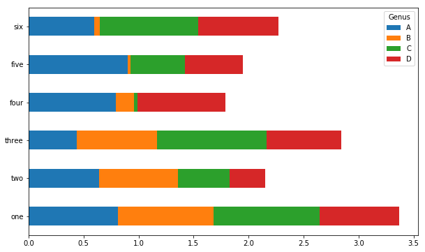

```python
df.plot(kind='barh', stacked=True)
```

1. 아래와 같이 육가공 식품 데이터를 포함하는 data 객체가 있을 때 원재료인 동물 정보를 포함하는 ‘animal’ 열을 추가하는 구문을 작성하라.

```python
data = DataFrame(
    [['bacon', 4.0],
     ['pulled pork', 3.0],
     ['bacon', 12.0],
     ['Pastrami', 6.0],
     ['corned beef', 7.5],
     ['Bacon',8.0]],
columns=['food', 'ounces'])
```

```python
mapping = {'bacon':'pig', 'pulled pork':'pig', 'pastrami':'beef', 'corned beef':'beef'}
data['animal'] = data.food.map(lambda x: mapping[x.lower()])
```

```python
data
```

|  | food | ounces | animal |
| --- | --- | --- | --- |
| 0 | bacon | 4.0 | pig |
| 1 | pulled pork | 3.0 | pig |
| 2 | bacon | 12.0 | pig |
| 3 | Pastrami | 6.0 | beef |
| 4 | corned beef | 7.5 | beef |
| 5 | Bacon | 8.0 | pig |

1. 아래와 같은 DataFrame 객체 df1과 df2를 생성하고 이 두 객체를 병합하여 합집합인 DataFrame이 되도록 하는 구문을 작성하라.

```python
df1 = DataFrame([[0, 'b'], [1, 'b'], [2, 'a'], [3, 'c'], [4, 'a'], [5, 'b']],
               columns=['data1', 'key'])
df2 = DataFrame([[0, 'a'], [1, 'b'], [2, 'a'], [3, 'b'], [4, 'd']],
               columns=['data2', 'key'])
```

```python
pd.merge(df1, df2, on='key', how='outer')
```

|  | data1 | key | data2 |
| --- | --- | --- | --- |
| 0 | 0.0 | b | 1.0 |
| 1 | 0.0 | b | 3.0 |
| 2 | 1.0 | b | 1.0 |
| 3 | 1.0 | b | 3.0 |
| 4 | 5.0 | b | 1.0 |
| 5 | 5.0 | b | 3.0 |
| 6 | 2.0 | a | 0.0 |
| 7 | 2.0 | a | 2.0 |
| 8 | 4.0 | a | 0.0 |
| 9 | 4.0 | a | 2.0 |
| 10 | 3.0 | c | NaN |
| 11 | NaN | d | 4.0 |